# Investigate Titanic Dataset.

- Introduction
- Data Wrangling
- Exploratory Data Analysis
- Conclusions

## Introduction

You can view a description of this dataset on [Kaggle](https://www.kaggle.com/c/titanic/data), where the data was obtained.

> "One of the reasons that the shipwreck led to such loss of life was that there were not enough lifeboats for the passengers and crew. Although there was some element of luck involved in surviving the sinking, some groups of people were more likely to survive than others, such as women, children, and the upper-class." - [Kaggle](https://www.kaggle.com/c/titanic).

```python
# Render plots inline
%matplotlib inline

# Import libraries
import pandas as pd
import numpy as np
import matplotlib.pyplot as plt
import seaborn as sns
```

## Data Wrangling

> In this section of the report, the following tasks are performed:
> - Loading the data
> - Cleaning of dataset for analysis.

```python
# Read in the dataset, create dataframe
titanic_data = pd.read_csv('D:/titanic_data.csv')

# Print the first few records to review data and format
titanic_data.head()
```

|  | PassengerId | Survived | Pclass | Name | Sex | Age | SibSp | Parch | Ticket | Fare | Cabin | Embarked |
| --- | --- | --- | --- | --- | --- | --- | --- | --- | --- | --- | --- | --- |
| 0 | 1 | 0 | 3 | Braund, Mr. Owen Harris | male | 22.0 | 1 | 0 | A/5 21171 | 7.2500 | NaN | S |
| 1 | 2 | 1 | 1 | Cumings, Mrs. John Bradley (Florence Briggs Th... | female | 38.0 | 1 | 0 | PC 17599 | 71.2833 | C85 | C |
| 2 | 3 | 1 | 3 | Heikkinen, Miss. Laina | female | 26.0 | 0 | 0 | STON/O2. 3101282 | 7.9250 | NaN | S |
| 3 | 4 | 1 | 1 | Futrelle, Mrs. Jacques Heath (Lily May Peel) | female | 35.0 | 1 | 0 | 113803 | 53.1000 | C123 | S |
| 4 | 5 | 0 | 3 | Allen, Mr. William Henry | male | 35.0 | 0 | 0 | 373450 | 8.0500 | NaN | S |

### Data Description

- **survival:** Survival (0 = No; 1 = Yes)
- **pclass:** Passenger Class (1 = 1st; 2 = 2nd; 3 = 3rd)
- **name:** Name
- **sex:** Sex
- **age:** Age
- **sibsp:** Number of Siblings/Spouses Aboard
- **parch:** Number of Parents/Children Aboard
- **ticket:** Ticket Number
- **fare:** Passenger Fare
- **cabin:** Cabin
- **embarked:** Port of Embarkation (C = Cherbourg; Q = Queenstown; S = Southampton)
- **Pclass** is a proxy for socio-economic status (SES) 1st ~ Upper; 2nd ~ Middle; 3rd ~ Lower
- **Age** is in Years; Fractional if Age less than One (1) If the Age is Estimated, it is in the form xx.5
- **Sibling:** Brother, Sister, Stepbrother, or Stepsister of Passenger Aboard Titanic
- **Spouse:** Husband or Wife of Passenger Aboard Titanic (Mistresses and Fiances Ignored)
- **Parent:** Mother or Father of Passenger Aboard Titanic
- **Child:** Son, Daughter, Stepson, or Stepdaughter of Passenger Aboard Titanic

### Data Cleaning

Some dataset columns will not play a part in analysis and these columns can therefore be removed.

- PassengerId
- Name
- Ticket
- Cabin
- Fare
- Embarked

```python
# Identify and remove duplicate entries
titanic_data.duplicated().sum()
```

```
0
```

```python
# Create new dataset without unwanted columns
titanic_data_cleaned = titanic_data.drop(['PassengerId','Name','Ticket','Cabin','Fare','Embarked'], axis=1)
titanic_data_cleaned.head()
```

|  | Survived | Pclass | Sex | Age | SibSp | Parch |
| --- | --- | --- | --- | --- | --- | --- |
| 0 | 0 | 3 | male | 22.0 | 1 | 0 |
| 1 | 1 | 1 | female | 38.0 | 1 | 0 |
| 2 | 1 | 3 | female | 26.0 | 0 | 0 |
| 3 | 1 | 1 | female | 35.0 | 1 | 0 |
| 4 | 0 | 3 | male | 35.0 | 0 | 0 |

#### Step 3 - Fix any missing or data format issues

```python
# Calculate number of missing values
titanic_data_cleaned.isnull().sum()
```

```
Survived      0
Pclass        0
Sex           0
Age         177
SibSp         0
Parch         0
dtype: int64
```

```python
# Review some of the missing Age data
missing_age_bool = pd.isnull(titanic_data_cleaned['Age'])
titanic_data_cleaned[missing_age_bool].head()
```

|  | Survived | Pclass | Sex | Age | SibSp | Parch |
| --- | --- | --- | --- | --- | --- | --- |
| 5 | 0 | 3 | male | NaN | 0 | 0 |
| 17 | 1 | 2 | male | NaN | 0 | 0 |
| 19 | 1 | 3 | female | NaN | 0 | 0 |
| 26 | 0 | 3 | male | NaN | 0 | 0 |
| 28 | 1 | 3 | female | NaN | 0 | 0 |

```python
# Determine number of males and females with missing age values
missing_age_female = titanic_data_cleaned[missing_age_bool]['Sex'] == 'female'
missing_age_male = titanic_data_cleaned[missing_age_bool]['Sex'] == 'male'

print('Number for females and males with age missing are {} and {} respectively'.format(missing_age_female.sum(),missing_age_male.sum()))
```

```
Number for females and males with age missing are 53 and 124 respectively
```

**Since age is not the deciding factors of death of passengers we will not fill them and count the missing values as 0. If needed, missing values will be filled further.**

```python
# Taking a look at the datatypes
titanic_data_cleaned.info()
```

```
<class 'pandas.core.frame.DataFrame'>
RangeIndex: 891 entries, 0 to 890
Data columns (total 6 columns):
 #   Column    Non-Null Count  Dtype
---  ------    --------------  -----
 0   Survived  891 non-null    int64
 1   Pclass    891 non-null    int64
 2   Sex       891 non-null    object
 3   Age       714 non-null    float64
 4   SibSp     891 non-null    int64
 5   Parch     891 non-null    int64
dtypes: float64(1), int64(4), object(1)
memory usage: 41.9+ KB
```

Missing Age data will affect but graphing shouldn't be a problem since they will be treated as 0. However, 177 is roughly 20% of our 891 sample dataset is a lot. This needs to be accounted for if reviewing descriptive stats such as mean age.

Should keep note of the proportions across male and female...

- Age missing in male data: **124**
- Age missing in female data: **53**

## Data Exploration and Visualization

```python
# Looking at some typical descriptive statistics
titanic_data_cleaned.describe()
```

|  | Survived | Pclass | Age | SibSp | Parch |
| --- | --- | --- | --- | --- | --- |
| count | 891.000000 | 891.000000 | 714.000000 | 891.000000 | 891.000000 |
| mean | 0.383838 | 2.308642 | 29.699118 | 0.523008 | 0.381594 |
| std | 0.486592 | 0.836071 | 14.526497 | 1.102743 | 0.806057 |
| min | 0.000000 | 1.000000 | 0.420000 | 0.000000 | 0.000000 |
| 25% | 0.000000 | 2.000000 | 20.125000 | 0.000000 | 0.000000 |
| 50% | 0.000000 | 3.000000 | 28.000000 | 0.000000 | 0.000000 |
| 75% | 1.000000 | 3.000000 | 38.000000 | 1.000000 | 0.000000 |
| max | 1.000000 | 3.000000 | 80.000000 | 8.000000 | 6.000000 |

```python
# Age min at 0.42 is odd.
titanic_data_cleaned[titanic_data_cleaned['Age'] < 1]
```

|  | Survived | Pclass | Sex | Age | SibSp | Parch |
| --- | --- | --- | --- | --- | --- | --- |
| 78 | 1 | 2 | male | 0.83 | 0 | 2 |
| 305 | 1 | 1 | male | 0.92 | 1 | 2 |
| 469 | 1 | 3 | female | 0.75 | 2 | 1 |
| 644 | 1 | 3 | female | 0.75 | 2 | 1 |
| 755 | 1 | 2 | male | 0.67 | 1 | 1 |
| 803 | 1 | 3 | male | 0.42 | 0 | 1 |
| 831 | 1 | 2 | male | 0.83 | 1 | 1 |

```python
# Taking a look at some survival rates for babies
youngest_to_survive = titanic_data_cleaned[titanic_data_cleaned['Survived'] == True]['Age'].min()
youngest_to_die = titanic_data_cleaned[titanic_data_cleaned['Survived'] == False]['Age'].min()
oldest_to_survive = titanic_data_cleaned[titanic_data_cleaned['Survived'] == True]['Age'].max()
oldest_to_die = titanic_data_cleaned[titanic_data_cleaned['Survived'] == False]['Age'].max()

print('Youngest to survive: {} \nYoungest to die: {} \nOldest to survive: {} \nOldest to die: {}'.format(
youngest_to_survive, youngest_to_die, oldest_to_survive, oldest_to_die))
```

```
Youngest to survive: 0.42
Youngest to die: 1.0
Oldest to survive: 80.0
Oldest to die: 74.0
```

**Stats :**

- Oldest to survive: **80**
- Oldest to die: **74**
- Youngest to survive: **< 1 (0.42)**
- Youngest to die: **1**

### Were Socio - Economic standing a factor in Survival Rate?

```python
# Returns survival rate/percentage of sex and class
def survival_rate(pclass, sex):
    grouped_by_total = titanic_data_cleaned.groupby(['Pclass', 'Sex']).size()[pclass,sex].astype('float')
    grouped_by_survived_sex = \
        titanic_data_cleaned.groupby(['Pclass','Survived','Sex']).size()[pclass,1,sex].astype('float')
    survived_sex_pct = (grouped_by_survived_sex / grouped_by_total * 100).round(2)

    return survived_sex_pct
```

```
Pclass  Survived  Sex
1       0         female      3
                  male       77
        1         female     91
                  male       45
2       0         female      6
                  male       91
        1         female     70
                  male       17
3       0         female     72
                  male      300
        1         female     72
                  male       47
dtype: int64
Class 1 - female survival rate: 96.81%
Class 1 - male survival rate: 36.89%
Class 2 - female survival rate: 92.11%
Class 2 - male survival rate: 15.74%
Class 3 - female survival rate: 50.0%
Class 3 - male survival rate: 13.54%
```

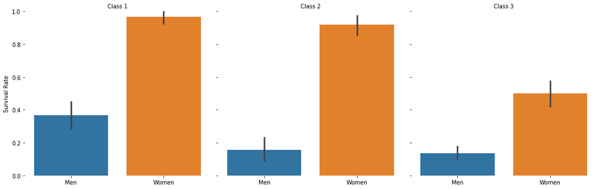

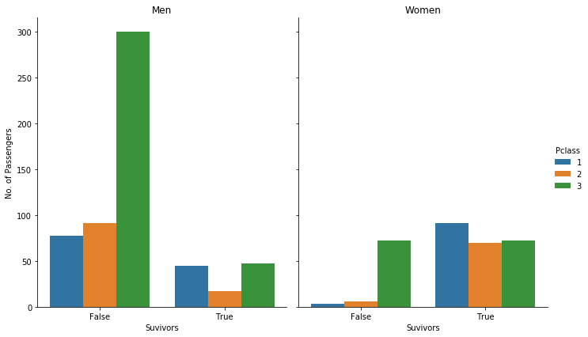

```python
# Getting the actual numbers grouped by class, suvival and sex
groupedby_class_survived_size = titanic_data_cleaned.groupby(['Pclass','Survived','Sex']).size()

# Printing Grouped by class, survival and sex
print (groupedby_class_survived_size)
print('Class 1 - female survival rate: {}%'.format(survival_rate(1,'female')))
print ('Class 1 - male survival rate: {}%'.format(survival_rate(1,'male')))

print ('Class 2 - female survival rate: {}%'.format(survival_rate(2,'female')))
print ('Class 2 - male survival rate: {}%'.format(survival_rate(2,'male')))

print ('Class 3 - female survival rate: {}%'.format(survival_rate(3,'female')))
print ('Class 3 - male survival rate: {}%'.format(survival_rate(3,'male')))

# Graph of Grouped by class, survival and sex
g = sns.catplot(x="Sex", y="Survived", col="Pclass", data=titanic_data_cleaned
                   , kind="bar")

# Fix up the labels
(g.set_axis_labels('', 'Survival Rate')
     .set_xticklabels(["Men", "Women"])
     .set_titles("Class {col_name}")
     .set(ylim=(0, 1))
     .despine(left=True, bottom=True))

# Graph - Actual count of passengers by survival, group and sex
g = sns.catplot('Survived', col='Sex', hue='Pclass', data=titanic_data_cleaned, kind='count', height=6, aspect=.8)

# Fix up the labels
(g.set_axis_labels('Suvivors', 'No. of Passengers')
    .set_xticklabels(["False", "True"])
    .set_titles('{col_name}'))
titles = ['Men', 'Women']
for ax, title in zip(g.axes.flat, titles):
    ax.set_title(title)
```

Based on the raw numbers it would appear as though passengers in Class 3 had a similar survival rate as those from Class 1 with **119 and 136 passengers surviving respectively.** However, looking at the percentages of the overall passengers per class and the total numbers across each class, it can be assumed that **a passenger from Class 1 is about 2.5x times more likely to survive than a passenger in Class 3.**

Social-economic standing was a factor in survival rate of passengers.

- Class 1: **62.96%**
- Class 2: **47.28%**
- Class 3: **24.24%**

### Did age, regardless of sex and class, determine your chances of Survival?

```
Number of men and woman with age missing are 53 and 124 respectively
Total number of survivors 290
Total number of non survivors 424
Mean age of survivors 28.0
Mean age of non survivors 31.0
Oldest to survive 80.0
Oldest to not survive 74.0
```

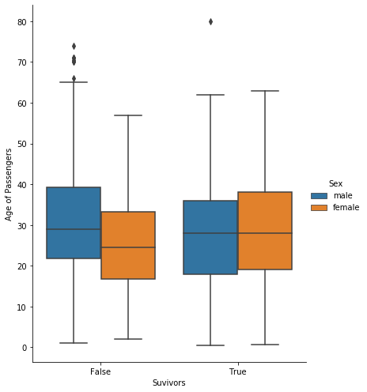

```python
# Let us first identify and get rid of records with missing Age
print ('Number of men and woman with age missing are {} and {} respectively'.format(missing_age_female.sum(),missing_age_male.sum()))

# Drop the NaN values. Calculations will be okay with them (seen as zero) but will throw off averages and counts
titanic_data_age_cleaned = titanic_data_cleaned.dropna()

# Find total count of survivors and those who didn't
number_survived = titanic_data_age_cleaned[titanic_data_age_cleaned['Survived'] == True]['Survived'].count()
number_died = titanic_data_age_cleaned[titanic_data_age_cleaned['Survived'] == False]['Survived'].count()

# Find average of survivors and those who didn't
mean_age_survived = titanic_data_age_cleaned[titanic_data_age_cleaned['Survived'] == True]['Age'].mean()
mean_age_died = titanic_data_age_cleaned[titanic_data_age_cleaned['Survived'] == False]['Age'].mean()

# Display a few raw totals
print ('Total number of survivors {} \n\
Total number of non survivors {} \n\
Mean age of survivors {} \n\
Mean age of non survivors {} \n\
Oldest to survive {} \n\
Oldest to not survive {}' \
.format(number_survived, number_died, np.round(mean_age_survived),
        np.round(mean_age_died), oldest_to_survive, oldest_to_die))

# Graph - Age of passengers across sex of those who survived
g = sns.catplot(x="Survived", y="Age", hue='Sex', data=titanic_data_age_cleaned, kind="box", size=7, aspect=.8)

# Fix up the labels
(g.set_axis_labels('Suvivors', 'Age of Passengers')
    .set_xticklabels(["False", "True"])
)
```

- Regardless of sex and class, age was not a deciding factor in the passenger survival rate.
- Average age for those who survived and even those who did not survive were inline with each other.

### Did women and children have higher preference to lifeboats and therefore survival (Assuming there was no shortage of Lifeboats)?

```
Category  Survived
Child     0            52
          1            61
Man       0           325
          1            70
Woman     0            47
          1           159
dtype: int64
```

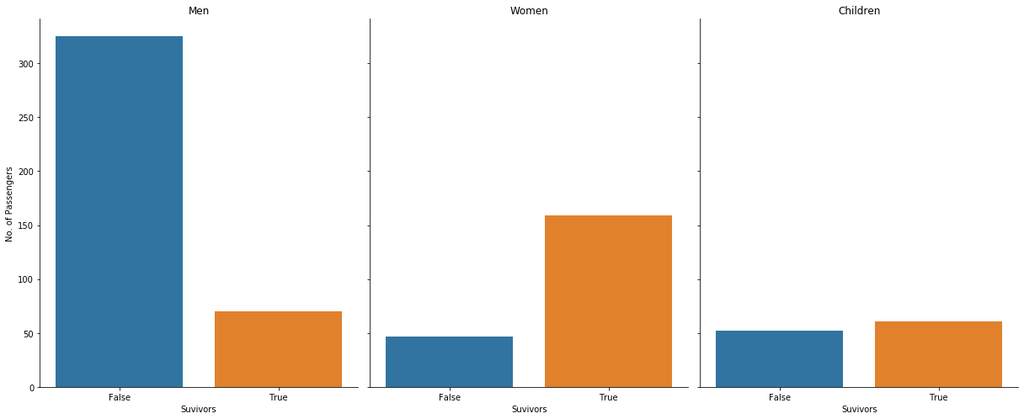

```python
# Creating Cateogry column and categorize people
titanic_data_age_cleaned.loc[
    ( (titanic_data_age_cleaned['Sex'] == 'female') &
    (titanic_data_age_cleaned['Age'] >= 18) ),
    'Category'] = 'Woman'

titanic_data_age_cleaned.loc[
    ( (titanic_data_age_cleaned['Sex'] == 'male') &
    (titanic_data_age_cleaned['Age'] >= 18) ),
    'Category'] = 'Man'

titanic_data_age_cleaned.loc[
    (titanic_data_age_cleaned['Age'] < 18),
    'Category'] = 'Child'

# Getting the totals grouped by Men, Women and Children, and by survival
print (titanic_data_age_cleaned.groupby(['Category','Survived']).size())

# Graph - Compare survival count between Men, Women and Children
g = sns.catplot('Survived', col='Category', data=titanic_data_age_cleaned, kind='count', size=7, aspect=.8)

(g.set_axis_labels('Suvivors', 'No. of Passengers')
    .set_xticklabels(['False', 'True'])
)

titles = ['Men', 'Women', 'Children']
for ax, title in zip(g.axes.flat, titles):
    ax.set_title(title)
```

The data and the graphs supports the idea that "women and children first" played a role in the survival of a number of people. It's surprising that more children didn't survive but this could possibly be attributed to the mis-representation of what age is considered as the cut off for adults - i.e. if in the 1900's someone 15-17 were considered adults, they would not have been "saved" under the "women and children first" idea and would be made to fend for themselves.

```python
# Determine number of woman that are not parents
titanic_data_woman_parents = titanic_data_age_cleaned.loc[
    (titanic_data_age_cleaned['Category'] == 'Woman') &
    (titanic_data_age_cleaned['Parch'] > 0)]

# Determine number of woman over 20 that are not parents
titanic_data_woman_parents_maybe = titanic_data_age_cleaned.loc[
    (titanic_data_age_cleaned['Category'] == 'Woman') &
    (titanic_data_age_cleaned['Parch'] > 0) &
    (titanic_data_age_cleaned['Age'] > 20)]
```

```python
titanic_data_woman_parents.head()
```

|  | Survived | Pclass | Sex | Age | SibSp | Parch | Category |
| --- | --- | --- | --- | --- | --- | --- | --- |
| 8 | 1 | 3 | female | 27.0 | 0 | 2 | Woman |
| 25 | 1 | 3 | female | 38.0 | 1 | 5 | Woman |
| 88 | 1 | 1 | female | 23.0 | 3 | 2 | Woman |
| 98 | 1 | 2 | female | 34.0 | 0 | 1 | Woman |
| 136 | 1 | 1 | female | 19.0 | 0 | 2 | Woman |

```python
titanic_data_woman_parents_maybe.head()
```

|  | Survived | Pclass | Sex | Age | SibSp | Parch | Category |
| --- | --- | --- | --- | --- | --- | --- | --- |
| 8 | 1 | 3 | female | 27.0 | 0 | 2 | Woman |
| 25 | 1 | 3 | female | 38.0 | 1 | 5 | Woman |
| 88 | 1 | 1 | female | 23.0 | 3 | 2 | Woman |
| 98 | 1 | 2 | female | 34.0 | 0 | 1 | Woman |
| 167 | 0 | 3 | female | 45.0 | 1 | 4 | Woman |

### How did children with nannies fare in comparison to children with parents. Did the nanny "abandon" children to save his/her own life?

```python
# Separate out children with parents from those with nannies
titanic_data_children_nannies = titanic_data_age_cleaned.loc[
    (titanic_data_age_cleaned['Category'] == 'Child') &
    (titanic_data_age_cleaned['Parch'] == 0)]

titanic_data_children_parents = titanic_data_age_cleaned.loc[
    (titanic_data_age_cleaned['Category'] == 'Child') &
    (titanic_data_age_cleaned['Parch'] > 0)]
```

```python
# Determine children with nannies who survived and who did not
survived_children_nannies = titanic_data_children_nannies.Survived.sum()
total_children_nannies = titanic_data_children_nannies.Survived.count()
pct_survived_nannies = ((float(survived_children_nannies)/total_children_nannies)*100)
pct_survived_nannies = np.round(pct_survived_nannies,2)
survived_children_nannies_avg_age = np.round(titanic_data_children_nannies.Age.mean())

# Display results
print ('Total number of children with nannies: {}\n\
Children with nannies who survived: {}\n\
Children with nannies who did not survive: {}\n\
Percentage of children who survived: {}%\n\
Average age of surviving children: {}'\
.format(total_children_nannies, survived_children_nannies,
        total_children_nannies-survived_children_nannies, pct_survived_nannies, survived_children_nannies_avg_age))

# Verify counts (looked a bit too evenly divided)
titanic_data_children_nannies.loc[titanic_data_children_nannies['Survived'] == 1]
```

```
Total number of children with nannies: 32
Children with nannies who survived: 16
Children with nannies who did not survive: 16
Percentage of children who survived: 50.0%
Average age of surviving children: 15.0
```

|  | Survived | Pclass | Sex | Age | SibSp | Parch | Category |
| --- | --- | --- | --- | --- | --- | --- | --- |
| 9 | 1 | 2 | female | 14.0 | 1 | 0 | Child |
| 22 | 1 | 3 | female | 15.0 | 0 | 0 | Child |
| 39 | 1 | 3 | female | 14.0 | 1 | 0 | Child |
| 84 | 1 | 2 | female | 17.0 | 0 | 0 | Child |
| 125 | 1 | 3 | male | 12.0 | 1 | 0 | Child |
| 156 | 1 | 3 | female | 16.0 | 0 | 0 | Child |
| 208 | 1 | 3 | female | 16.0 | 0 | 0 | Child |
| 220 | 1 | 3 | male | 16.0 | 0 | 0 | Child |
| 307 | 1 | 1 | female | 17.0 | 1 | 0 | Child |
| 389 | 1 | 2 | female | 17.0 | 0 | 0 | Child |
| 504 | 1 | 1 | female | 16.0 | 0 | 0 | Child |
| 777 | 1 | 3 | female | 5.0 | 0 | 0 | Child |
| 780 | 1 | 3 | female | 13.0 | 0 | 0 | Child |
| 781 | 1 | 1 | female | 17.0 | 1 | 0 | Child |
| 830 | 1 | 3 | female | 15.0 | 1 | 0 | Child |
| 875 | 1 | 3 | female | 15.0 | 0 | 0 | Child |

```python
# Determine children with parents who survived and who did not
survived_children_parents = titanic_data_children_parents.Survived.sum()
total_children_parents = titanic_data_children_parents.Survived.count()
pct_survived_parents = ((float(survived_children_parents)/total_children_parents)*100)
pct_survived_parents = np.round(pct_survived_parents,2)
survived_children_parents_avg_age = np.round(titanic_data_children_parents.Age.mean())

# Display results
print ('Total number of children with parents: {}\n\
Children with parents who survived: {}\n\
Children with parents who did not survive: {}\n\
Percentage of children who survived: {}%\n\
Average age of surviving children: {}'\
.format(total_children_parents, survived_children_parents,
        total_children_parents-survived_children_parents, pct_survived_parents,survived_children_parents_avg_age))
```

```
Total number of children with parents: 81
Children with parents who survived: 45
Children with parents who did not survive: 36
Percentage of children who survived: 55.56%
Average age of surviving children: 7.0
```

Based on the data analysis, it appears that the survival rate for children who were accompanied by parents vs those children accompanied by nannies was slighly higher for those with parents. The slight increase could be due to the average age of children with parents being younger, almost half, that of children with nannies.

- Percentage of children with nannies who survived: **50.0%**
- Percentage of children with parents who survived: **55.56%**
- Average age of surviving children with nannies: **15**
- Average age of surviving children with parents: **7.0**